# Load data into R and transform

```r
knitr::opts_chunk$set(echo = T, message = FALSE, warning = FALSE)
stdt<-date()

# Libraries
library(tidyverse)
library(Seurat)
library(cowplot)

# Input paths
wd <- "/hpc/group/chsi-mic-2022"
datadirs <- list.files(path = file.path(wd, "data","Christian2021CellReports"),
                       pattern = "_10x", full.names = T)
datadirs <- datadirs[!grepl(".h5", datadirs)]
intermeddir <- file.path(wd, "intermed")

# Output paths
scratchdir <- "/work"
username <- Sys.info()[["user"]]
outdir <- file.path(scratchdir,username,"output")
#dir.create(outdir) # uncomment if not already there
```

**Goal of this workshop:** Learn how to load cellranger output into R and prepare QC’d data for downstream analyses

**What’s covered in this workshop:** - Load data into R as a Seurat object - Verify that the data have been QC’d - Transform gene counts

**Data source:** Christian et al. 2021 Cell Reports (https://doi.org/10.1016/j.celrep.2021.109118)

Note that the Seurat - Guided Clustering Tutorial (https://satijalab.org/seurat/articles/pbmc3k_tutorial.html) includes a lot of overlapping information.

**METHOD DETAILS, Single-cell RNA-seq analysis, page e4**

- Pre-processing: “Raw short reads were demultiplexed, filtering and mapped to mouse genome GRCm38/mm10 using cellranger v2.02.”
- QC: “The gene count matrices from cellranger were subjected to quality control, pre-processing and clustering using the R Seurat 2.3.4 package (Butler et al., 2018). Low-quality cells that had less than 200 expressed genes and more than 5% mitochondrial genes were filtered out.”
- Analysis: “Gene counts were scaled to total gene expression and percentage of mitochondrial genes with a scaling factor of 10,000, and then log-transformed. The high dimensional data for each sample were reduced by PCA and t-Distributed Stochastics Neighbor Embedding (tSNE). We used the FindCluster function to group clusters in each sample with a resolution of 0.6. Differential expressed genes (DEGs) were identified using the Wilcoxon rank-sum test.”

## 1. Load data into R as a Seurat object

We can use code like this to load the cell ranger output and store it in a Seurat object.

```r
readin_10x_to_SO <- function(sample, path, min.cells = 0, min.genes = 0){
  Seurat::Read10X(data.dir = path) %>%
    Seurat::CreateSeuratObject(project = sample,
                               min.cells=min.cells, min.genes=min.genes) -> seu.obj
  return(seu.obj)
}
```

Load the four 10x datasets that correspond to T cells sampled in and outside of the tumor. See Fig 2A for tSNE plots of each sample type.

- Tem = effector memory in tumor
- Tcm = central memory in tumor
- Trm = resident memory in tumor
- disTrm = resident memory T-cells outside of the tumor

```r
sampleNames <- gsub("_10x","", basename(datadirs))
sampleNames
```

```
[1] "disTrm" "Tcm"    "Tem"    "Trm"
```

```r
seulist <- list()
for(i in 1:length(sampleNames)){
  seulist[[i]] <- readin_10x_to_SO(sample = sampleNames[i], path = datadirs[i])
}
names(seulist) <- sampleNames
seulist
```

```
$disTrm
An object of class Seurat
12064 features across 863 samples within 1 assay
Active assay: RNA (12064 features, 0 variable features)

$Tcm
An object of class Seurat
12840 features across 4009 samples within 1 assay
Active assay: RNA (12840 features, 0 variable features)

$Tem
An object of class Seurat
12571 features across 1457 samples within 1 assay
Active assay: RNA (12571 features, 0 variable features)

$Trm
An object of class Seurat
11778 features across 459 samples within 1 assay
Active assay: RNA (11778 features, 0 variable features)
```

## 2. Verify data have been QC’d

*METHOD DETAILS, Single-cell RNA-seq analysis, page e4*: “Low-quality cells that had less than 200 expressed genes and more than 5% mitochondrial genes were filtered out.”

The rownames are gene symbols. Investigating the names a bit more, the mitochondrial genes can be identified by the prefix “mt-”

```r
tem <- seulist$Tem
curr.count <- tem@assays$RNA@counts
rownames(curr.count)[1:10]
```

```
 [1] "Mrpl15"        "Lypla1"        "Tcea1"         "Atp6v1h"       "Rb1cc1"        "4732440D04Rik" "Pcmtd1"
 [8] "Gm26901"       "Rrs1"          "Mybl1"
```

```r
rownames(curr.count)[grepl("^mt-", rownames(curr.count))] # these look like mitochondrial genes!
```

```
 [1] "mt-Nd1"  "mt-Nd2"  "mt-Co1"  "mt-Co2"  "mt-Atp8" "mt-Atp6" "mt-Co3"  "mt-Nd3"  "mt-Nd4l" "mt-Nd4"  "mt-Nd5"  "mt-Nd6"
[13] "mt-Cytb"
```

Add the mitochondrial percentage for all seurat objects in our list

```r
add_mt <- function(so){
  so[["percent.mt"]] <- PercentageFeatureSet(so, pattern = "^mt-")
  return(so)
}

seulist %>%
  map(~add_mt(.x)) -> seulist.mt

seulist.mt %>%
  map(~head(.x@meta.data))
```

|  | orig.ident | nCount_RNA | nFeature_RNA | percent.mt |
| --- | --- | --- | --- | --- |
| AAACCTGAGTCCTCCT | disTrm | 2459 | 963 | 3.538024 |
| AAACCTGCACTTAAGC | disTrm | 3035 | 1038 | 3.228995 |
| AAACCTGTCTGATACG | disTrm | 6070 | 1745 | 2.075783 |
| AAACGGGAGCGATCCC | disTrm | 8625 | 1700 | 3.524638 |
| AAAGTAGCACATGTGT | disTrm | 3969 | 1403 | 2.670698 |
| AAATGCCGTCAATACC | disTrm | 2712 | 968 | 2.138643 |

|  | orig.ident | nCount_RNA | nFeature_RNA | percent.mt |
| --- | --- | --- | --- | --- |
| AAACCTGCAGGTGGAT | Tcm | 3597 | 1142 | 2.224076 |
| AAACCTGGTACGCTGC | Tcm | 4175 | 1185 | 2.419162 |
| AAACCTGGTCAGTGGA | Tcm | 5912 | 1472 | 1.962111 |
| AAACCTGGTCGTTGTA | Tcm | 8476 | 1948 | 2.524776 |
| AAACCTGTCACGAAGG | Tcm | 3934 | 1104 | 3.050330 |
| AAACCTGTCAGCTGGC | Tcm | 4090 | 1189 | 3.056235 |

|  | orig.ident | nCount_RNA | nFeature_RNA | percent.mt |
| --- | --- | --- | --- | --- |
| AAACCTGCAAGGTTCT | Tem | 6011 | 1797 | 0.9316254 |
| AAACCTGCACGCGAAA | Tem | 3740 | 1186 | 2.7005348 |
| AAACCTGGTATGGTTC | Tem | 1861 | 776 | 2.4180548 |
| AAACCTGTCTGGTATG | Tem | 2336 | 955 | 2.0547945 |
| AAACGGGCATGCCTAA | Tem | 6249 | 1539 | 2.2083533 |
| AAACGGGGTCTGATTG | Tem | 9313 | 2374 | 2.2549125 |

|  | orig.ident | nCount_RNA | nFeature_RNA | percent.mt |
| --- | --- | --- | --- | --- |
| AAACCTGGTCTTGCGG | Trm | 4480 | 1544 | 2.343750 |
| AAACGGGAGGCTCAGA | Trm | 7628 | 1696 | 3.224961 |
| AAACGGGGTCAACATC | Trm | 4830 | 1572 | 2.939959 |
| AAACGGGTCTTGAGAC | Trm | 8058 | 2239 | 2.593696 |
| AAAGATGGTAGGGTAC | Trm | 2378 | 1003 | 3.195963 |
| AAAGATGTCCTACAGA | Trm | 2934 | 1027 | 2.453988 |

```r
seulist <- seulist.mt
```

Examine the distribution of nFeature and nCount for each dataset

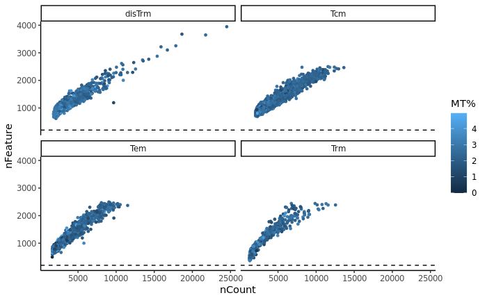

```r
seulist %>%
  map_dfr(~.x@meta.data, .id = "seuobj") %>%
  ggplot(aes(x = nCount_RNA, y = nFeature_RNA,
                color = percent.mt))+
    geom_point(size = 1)+
    facet_wrap(~ seuobj, nrow = 2)+
    labs(x = "nCount", y = "nFeature", color = "MT%") +
  theme_classic() +
  geom_hline(yintercept = 200, linetype = 2)
```

Are there any cells with less than 200 expressed genes?

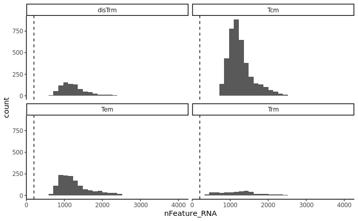

```r
seulist %>%
  map_dfr(~.x@meta.data, .id = "seuobj") %>%
  ggplot(aes(x = nFeature_RNA))+
    geom_histogram() +
    facet_wrap(~ seuobj, nrow = 2)+
  theme_classic() +
  geom_vline(xintercept = 200, linetype = 2)
```

Summarize as a table

```r
seulist %>%
  map_dfr(~.x@meta.data, .id = "seuobj") %>%
  group_by(seuobj) %>%
  summarize(min = min(nFeature_RNA),
            mean = mean(nFeature_RNA),
            max = max(nFeature_RNA))
```

| seuobj | min | mean | max |
| --- | --- | --- | --- |
| disTrm | 622 | 1265.912 | 3947 |
| Tcm | 686 | 1258.717 | 2499 |
| Tem | 500 | 1268.495 | 2495 |
| Trm | 372 | 1244.065 | 2442 |

Are there any cells with more than 5% mitochondrial genes?

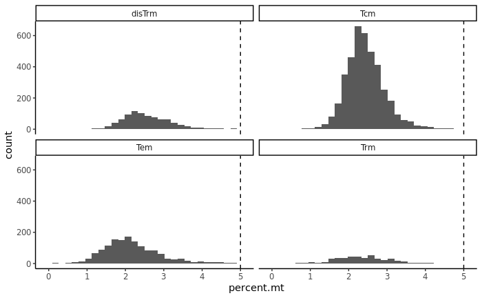

```r
seulist %>%
  map_dfr(~.x@meta.data, .id = "seuobj") %>%
  ggplot(aes(x = percent.mt))+
    geom_histogram() +
    facet_wrap(~ seuobj, nrow = 2)+
  theme_classic() +
  geom_vline(xintercept = 5, linetype = 2)
```

Summarize as a table

```r
seulist %>%
  map_dfr(~.x@meta.data, .id = "seuobj") %>%
  group_by(seuobj) %>%
  summarize(min = min(percent.mt),
            mean = mean(percent.mt),
            max = max(percent.mt))
```

| seuobj | min | mean | max |
| --- | --- | --- | --- |
| disTrm | 0.8255366 | 2.562216 | 4.888039 |
| Tcm | 0.6540019 | 2.441314 | 4.828367 |
| Tem | 0.0000000 | 2.175146 | 4.952538 |
| Trm | 0.4261364 | 2.352405 | 4.456825 |

## 3. Transform gene counts

*METHOD DETAILS, Single-cell RNA-seq analysis, page e4*: “Gene counts were scaled to total gene expression and percentage of mitochondrial genes with a scaling factor of 10,000, and then log-transformed.”

First, take a look at how data are structured inside the filtered seurat object

```r
tem <- seulist$Tem

Assays(tem)
```

```
[1] "RNA"
```

```r
tem@assays
```

```
$RNA
Assay data with 12571 features for 1457 cells
First 10 features:
 Mrpl15, Lypla1, Tcea1, Atp6v1h, Rb1cc1, 4732440D04Rik, Pcmtd1, Gm26901, Rrs1, Mybl1
```

There is 1 assay called “RNA”. Inside this, there are 3 slots for matrices named “counts”, “data”, and “scale.data”. Each matrix consists of rows = features and columns = cells.

```r
curr.counts <- tem@assays$RNA@counts
dim(curr.counts) # 12571 features as rows and 1457 cells as columns
```

```
[1] 12571  1457
```

```r
colnames(curr.counts)[1:10]
```

```
 [1] "AAACCTGCAAGGTTCT" "AAACCTGCACGCGAAA" "AAACCTGGTATGGTTC" "AAACCTGTCTGGTATG" "AAACGGGCATGCCTAA" "AAACGGGGTCTGATTG"
 [7] "AAACGGGTCACCTCGT" "AAACGGGTCTTCAACT" "AAAGATGAGTCAATAG" "AAAGATGGTCTTGATG"
```

```r
rownames(curr.counts)[1:10]
```

```
 [1] "Mrpl15"        "Lypla1"        "Tcea1"         "Atp6v1h"       "Rb1cc1"        "4732440D04Rik" "Pcmtd1"
 [8] "Gm26901"       "Rrs1"          "Mybl1"
```

```r
curr.data <- tem@assays$RNA@data
dim(curr.data) # 12571 features as rows and 1457 cells as columns
```

```
[1] 12571  1457
```

```r
colnames(curr.data)[1:10]
```

```
 [1] "AAACCTGCAAGGTTCT" "AAACCTGCACGCGAAA" "AAACCTGGTATGGTTC" "AAACCTGTCTGGTATG" "AAACGGGCATGCCTAA" "AAACGGGGTCTGATTG"
 [7] "AAACGGGTCACCTCGT" "AAACGGGTCTTCAACT" "AAAGATGAGTCAATAG" "AAAGATGGTCTTGATG"
```

```r
rownames(curr.data)[1:10]
```

```
 [1] "Mrpl15"        "Lypla1"        "Tcea1"         "Atp6v1h"       "Rb1cc1"        "4732440D04Rik" "Pcmtd1"
 [8] "Gm26901"       "Rrs1"          "Mybl1"
```

```r
curr.scale.data <- tem@assays$RNA@scale.data
dim(curr.scale.data) # empty
```

```
[1] 0 0
```

Compare how the “counts” and “data” values differ. Pull out values for a single cell and plot.

```r
i <- 1
colnames(curr.counts)[i] # cell identifier
```

```
[1] "AAACCTGCAAGGTTCT"
```

```r
df <- data.frame(count = curr.counts[,i], data = curr.data[,i], feature = row.names(curr.counts), row.names = NULL)
head(df)
```

|  | count | data | feature |
| --- | --- | --- | --- |
| 1 | 1 | 1 | Mrpl15 |
| 2 | 2 | 2 | Lypla1 |
| 3 | 1 | 1 | Tcea1 |
| 4 | 1 | 1 | Atp6v1h |
| 5 | 1 | 1 | Rb1cc1 |
| 6 | 0 | 0 | 4732440D04Rik |

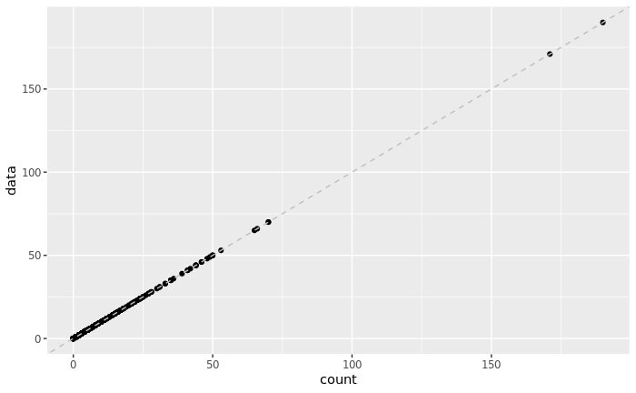

```r
ggplot(df, aes(x = count, y = data)) +
  geom_point() +
  geom_abline(slope = 1, intercept = 0, linetype = 2, color = "grey")
```

Normalize the counts and re-examine the data slots. Note that only the values in the “data” slot have changed.

```r
tem.s <- NormalizeData(object = tem, normalization.method = "LogNormalize", scale.factor = 10000)
s.counts <- tem.s@assays$RNA@counts
dim(s.counts) # 12571 features as rows and 1457 cells as columns
```

```
[1] 12571  1457
```

```r
s.counts[1:10,1:10]
```

```
10 x 10 sparse Matrix of class "dgCMatrix"
```

```
   [[ suppressing 10 column names ‘AAACCTGCAAGGTTCT’, ‘AAACCTGCACGCGAAA’, ‘AAACCTGGTATGGTTC’ ... ]]
```

```
Mrpl15        1 . . . . 1 . . . .
Lypla1        2 1 . . . 1 . . . .
Tcea1         1 . . 1 1 1 . . . 1
Atp6v1h       1 . . . . . . . . 1
Rb1cc1        1 . . . . . . . . .
4732440D04Rik . . . 1 . . . . . .
Pcmtd1        . . . . 1 . . . . .
Gm26901       . . . . . . . . . .
Rrs1          . . . . . . . . . 1
Mybl1         . . . . . . . . . .
```

```r
#colnames(s.counts)[1:10]
#rownames(s.counts)[1:10]

s.data <- tem.s@assays$RNA@data
dim(s.data) # 12571 features as rows and 1457 cells as columns
```

```
[1] 12571  1457
```

```r
s.data[1:10,1:10]
```

```
10 x 10 sparse Matrix of class "dgCMatrix"
```

```
   [[ suppressing 10 column names ‘AAACCTGCAAGGTTCT’, ‘AAACCTGCACGCGAAA’, ‘AAACCTGGTATGGTTC’ ... ]]
```

```
Mrpl15        0.9796849 .        . .        .         0.7293672 . . . .
Lypla1        1.4649284 1.301226 . .        .         0.7293672 . . . .
Tcea1         0.9796849 .        . 1.664082 0.9556099 0.7293672 . . . 0.8456252
Atp6v1h       0.9796849 .        . .        .         .         . . . 0.8456252
Rb1cc1        0.9796849 .        . .        .         .         . . . .
4732440D04Rik .         .        . 1.664082 .         .         . . . .
Pcmtd1        .         .        . .        0.9556099 .         . . . .
Gm26901       .         .        . .        .         .         . . . .
Rrs1          .         .        . .        .         .         . . . 0.8456252
Mybl1         .         .        . .        .         .         . . . .
```

```r
#colnames(s.data)[1:10]
#rownames(s.data)[1:10]

s.scale.data <- tem.s@assays$RNA@scale.data
dim(s.scale.data) # empty
```

```
[1] 0 0
```

```r
## plot
i <- 1
colnames(s.counts)[i] # cell identifier
```

```
[1] "AAACCTGCAAGGTTCT"
```

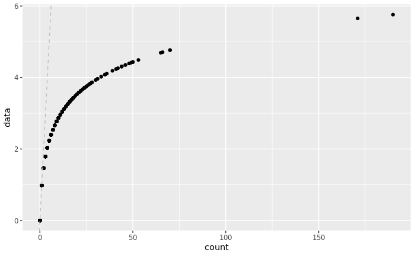

```r
df <- data.frame(count = s.counts[,i], data = s.data[,i], feature = row.names(s.counts), row.names = NULL)
ggplot(df, aes(x = count, y = data)) +
  geom_point() +
  geom_abline(slope = 1, intercept = 0, linetype = 2, color = "grey")
```

Normalize each of the seurat objects in the list.

Here is an example of how to do this with a for-loop

```r
sampleNames <- names(seulist)
seulist.n <- list()
for(i in 1:length(sampleNames)){
  seulist.n[[i]] <- NormalizeData(object = seulist[[i]], normalization.method = "LogNormalize",
                                  scale.factor = 10000)
}
names(seulist.n) <- sampleNames
```

Here is an example of how to this using purrr::map and pipes

```r
# seulist %>%
#   map(~NormalizeData(object = .x, normalization.method = "LogNormalize", scale.factor = 10000)) -> seulist.n
```